# Machine Learning with R

14 de diciembre de 2017

Disclaimer: These are just my notes from the DataCamp course. **Not intended for distribution.**

# Supervised Learning: Classification

## k-Nearest Neighbors (kNN)

Slides

### Recognizing a road sign with kNN

After several trips with a human behind the wheel, it is time for the self-driving car to attempt the test course alone.

Can you apply a kNN classifier to help the car recognize this sign?

**Instructions**

The dataset `signs` is loaded in your workspace along with the dataframe `next_sign`, which holds the observation you want to classify.

- Load the `class` package.
- Create a vector of sign labels to use with kNN by extracting the column `sign_type` from `signs`.
- Identify the `next_sign` using the `knn()` function.
- Set the `train` argument equal to the `signs` data frame without the first column.
- Set the `test` argument equal to the data frame `next_sign`.
- Use the vector of labels you created as the `cl` argument.

```r
# Load the 'class' package
library(class)

# Create a vector of labels
sign_types <- signs$sign_type

# Classify the next sign observed
knn(train = signs[,-1], test = next_sign, cl = sign_types)
```

```
## [1] stop
## Levels: pedestrian speed stop
```

### Exploring the traffic sign dataset

To better understand how the `knn()` function was able to classify the stop sign, it may help to examine the training dataset it used.

Each previously observed street sign was divided into a 4x4 grid, and the red, green, and blue level for each of the 16 center pixels is recorded as illustrated here.

[figure not shown]

The result is a dataset that records the `sign_type` as well as 16 x 3 = 48 color properties of each sign.

**Instructions**

- Use the `str()` function to examine the `signs` dataset.
- Use `table()` to count the number of observations of each sign type by passing it the column containing the labels.
- Run the provided `aggregate()` command to see whether the average red level might vary by sign type.

```r
# Examine the structure of the signs dataset
# str(signs)

# Count the number of signs of each type
table(signs$sign_type)
```

```
##
## pedestrian      speed       stop
##         46         49         51
```

```r
# Check r10's average red level by sign type
aggregate(r10 ~ sign_type, data = signs, mean)
```

```
##    sign_type       r10
## 1 pedestrian 113.71739
## 2      speed  80.63265
## 3       stop 132.39216
```

### Classifying a collection of road signs

Now that the autonomous vehicle has successfully stopped on its own, your team feels confident allowing the car to continue the test course.

At the conclusion of the trial, you are asked to measure the car’s overall performance at recognizing these signs.

**Intructions**

The class package and the dataset signs are already loaded in your workspace. So is the dataframe test_signs, which holds a set of observations you’ll test your model on.

- Classify the `test_signs` data using `knn()`.
- Set `train` equal to the observations in `signs` without labels.
- Use `test_signs` for the `test` argument, again without labels.
- For the `cl` argument, use the vector of labels provided for you.
- Use `table()` to explore the classifier’s performance at identifying the three sign types.
- Create the vector `signs_actual` by extracting the labels from `test_signs`.
- Pass the vector of predictions and the vector of actual signs to `table()` to cross tabulate them.
- Compute the overall accuracy of the kNN learner using the `mean()` function

```r
# Use kNN to identify the test road signs
sign_types <- signs$sign_type
signs_pred <- knn(train = signs[-1], test = test_signs[-1], cl = sign_types)

# Create a confusion matrix of the actual versus predicted values
signs_actual <- test_signs$sign_type
table(signs_pred, signs_actual)
```

```
##             signs_actual
## signs_pred   pedestrian speed stop
##   pedestrian         19     2    0
##   speed               0    17    0
##   stop                0     2   20
```

```r
# Compute the accuracy
mean(signs_pred == signs_actual)
```

```
## [1] 0.9333333
```

### Testing other ‘k’ values

By default, the `knn()` function in the class package uses only the single nearest neighbor.

Setting a `k` parameter allows the algorithm to consider additional nearby neighbors. This enlarges the collection of neighbors which will vote on the predicted class.

Compare `k` values of 1, 7, and 15 to examine the impact on traffic sign classification accuracy.

**Instructions**

The class package is already loaded in your workspace along with the datasets signs and signs_test. The object signs_actual holds the true values of the signs.

- Compute the accuracy of the default `k = 1` model using the given code.
- Modify the `knn()` function call by setting `k = 7`.
- Revise the code once more by setting `k = 15` and compare the three accuracy values.

```r
# Compute the accuracy of the baseline model (default k = 1)
k_1 <- knn(train = signs[-1], test = signs_test[-1], cl = signs$sign_type, k = 1)
mean(k_1 == signs_test$sign_type)
```

```
## [1] 0.9333333
```

```r
# Modify the above to set k = 7
k_7 <- knn(train = signs[-1], test = signs_test[-1], cl = signs$sign_type, k = 7)
mean(k_7 == signs_test$sign_type)
```

```
## [1] 0.9666667
```

```r
# Set k = 15 and compare to the above
k_15 <- knn(train = signs[-1], test = signs_test[-1], cl = signs$sign_type, k = 15)
mean(k_15 == signs_test$sign_type)
```

```
## [1] 0.9
```

### Seeing how the neighbors voted

When multiple nearest neighbors hold a vote, it can sometimes be useful to examine whether the voters were unanimous or widely separated.

For example, knowing more about the voters’ confidence in the classification could allow an autonomous vehicle to use caution in the case there is any chance at all that a stop sign is ahead.

In this exercise, you will learn how to obtain the voting results from the `knn()` function.

**Instructions**

The class package has already been loaded in your workspace along with the dataset signs.

- Build a kNN model with the `prob = TRUE` parameter to compute the vote proportions. Set `k = 7`.
- Use the `attr()` function to obtain the vote proportions for the predicted class. These are stored in the attribute `"prob"`.
- Examine the first several vote outcomes and percentages using the `head()` function to see how the confidence varies from sign to sign.

```r
# Use the prob parameter to get the proportion of votes for the winning class
sign_pred <- knn(train = signs[-1], test = signs_test[-1], cl = signs$sign_type, prob = T, k = 7)

# Get the "prob" attribute from the predicted classes
sign_prob <- attr(sign_pred, "prob")

# Examine the first several predictions
head(sign_pred)
```

```
## [1] pedestrian pedestrian pedestrian stop       pedestrian pedestrian
## Levels: pedestrian speed stop
```

```r
# Examine the proportion of votes for the winning class
head(sign_prob)
```

```
## [1] 0.5714286 0.5714286 0.8571429 0.5714286 0.8571429 0.5714286
```

## Naive Bayes

Slides

### Computing probabilities

The `where9am` data frame contains 91 days (thirteen weeks) worth of data in which Brett recorded his `location` at 9am each day as well as whether the daytype was a `weekend` or `weekday`.

Using the conditional probability formula below, you can compute the probability that Brett is working in the office, given that it is a weekday.

$$P(A\mid B)=\frac{P(A\land B)}{P(B)}$$

Calculations like these are the basis of the Naive Bayes destination prediction model you’ll develop in later exercises.

**Instructions**

```r
locations <- read.csv("Data/1Classification/locations.csv")

where9am <- locations %>%
  filter(hour == 9, hourtype == "morning") %>%
  select(daytype, location)
```

- Find $P(office)$ using `nrow()` and `subset()` to count rows in the dataset and save the result as `p_A`.
- Find $P(weekday)$, using `nrow()` and `subset()` again, and save the result as `p_B`.
- Use `nrow()` and `subset()` a final time to find $P(office \land weekday)$. Save the result as `p_AB`.
- Compute $P(office \mid weekday)$ and save the result as `p_A_given_B`.
- Print the value of `p_A_given_B`.

```r
# Compute P(A)
p_A <- nrow(subset(where9am, location == "office"))/nrow(where9am)

# Compute P(B)
p_B <- nrow(subset(where9am, daytype == "weekday"))/nrow(where9am)

# Compute the observed P(A and B)
p_AB <- nrow(subset(where9am, location == "office", daytype == "weekday"))/nrow(where9am)

# Compute P(A | B)
p_A_given_B <- p_AB/p_B
p_A_given_B
```

```
## [1] 0.6
```

### A simple Naive Bayes location model

The previous exercises showed that the probability that Brett is at work or at home at 9am is highly dependent on whether it is the weekend or a weekday.

To see this finding in action, use the `where9am` data frame to build a Naive Bayes model on the same data.

You can then use this model to predict the future: where does the model think that Brett will be at 9am on Thursday and at 9am on Saturday?

**Instructions**

The dataframe where9am is available in your workspace. This dataset contains information about Brett’s location at 9am on different days.

- Load the `naivebayes` package.
- Use `naive_bayes()` with a formula like `y ~ x` to build a model of `location` as a function of `daytype`.
- Forecast the Thursday 9am location using `predict()` with the `thursday9am` object as the newdata argument.
- Do the same for predicting the `saturday9am` location.

```r
# Load the naivebayes package
library(naivebayes)

# Build the location prediction model
locmodel <- naive_bayes(location ~ daytype, data = where9am)

# Predict Thursday's 9am location
predict(locmodel, thursday9am)
```

```
## [1] office
## Levels: appointment campus home office
```

```r
# Predict Saturdays's 9am location
predict(locmodel, saturday9am)
```

[output not shown]

### Examining “raw” probabilities

The `naivebayes` package offers several ways to peek inside a Naive Bayes model.

Typing the name of the model object provides the a priori (overall) and conditional probabilities of each of the model’s predictors. If one were so inclined, you might use these for calculating posterior (predicted) probabilities by hand.

Alternatively, R will compute the posterior probabilities for you if the `type = "prob"` parameter is supplied to the `predict()` function.

Using these methods, examine how the model’s predicted 9am location probability varies from day-to-day.

**Instructions**

The model `locmodel` that you fit in the previous exercise is in your workspace.

- Print the `locmodel` object to the console to view the computed a priori and conditional probabilities.
- Use the `predict()` function similarly to the previous exercise, but with `type = "prob"` to see the predicted probabilities for Thursday at 9am.
- Compare these to the predicted probabilities for Saturday at 9am.

```r
# The 'naivebayes' package is loaded into the workspace
# and the Naive Bayes 'locmodel' has been built

# Examine the location prediction model
locmodel
```

```
## ===================== Naive Bayes =====================
## Call:
## naive_bayes.formula(formula = location ~ daytype, data = where9am)
##
## A priori probabilities:
##
## appointment      campus        home      office
##  0.01098901  0.10989011  0.45054945  0.42857143
##
## Tables:
##
## daytype   appointment    campus      home    office
##   weekday   1.0000000 1.0000000 0.3658537 1.0000000
##   weekend   0.0000000 0.0000000 0.6341463 0.0000000
```

```r
# Obtain the predicted probabilities for Thursday at 9am
predict(locmodel, thursday9am , type = "prob")
```

```
##      appointment    campus      home office
## [1,]  0.01538462 0.1538462 0.2307692    0.6
```

```r
# Obtain the predicted probabilities for Saturday at 9am
predict(locmodel, saturday9am , type = "prob")
```

[output not shown]

### A more sophisticated location model

The `locations` dataset records Brett’s location every hour for 13 weeks. Each hour, the tracking information includes the `daytype` (weekend or weekday) as well as the `hourtype` (morning, afternoon, evening, or night).

Using this data, build a more sophisticated model to see how Brett’s predicted location not only varies by the day of week but also by the time of day.

**Instructions**

The dataset `locations` is already loaded in your workspace.

- Use the R formula interface to build a model where location depends on both `daytype` and `hourtype`. Recall that the function `naive_bayes()` takes 2 arguments: `formula` and `data`.
- Predict Brett’s location on a weekday afternoon using the dataframe `weekday_afternoon` and the `predict()` function.
- Do the same for a `weekday_evening`.

```r
# The 'naivebayes' package is loaded into the workspace already

# Build a NB model of location
locmodel <- naive_bayes(location ~ daytype + hourtype, data = locations)

# Predict Brett's location on a weekday afternoon
predict(locmodel, weekday_afternoon)
```

```
## [1] office
## Levels: appointment campus home office restaurant store theater
```

```r
# Predict Brett's location on a weekday evening
predict(locmodel, weekday_evening)
```

```
## [1] home
## Levels: appointment campus home office restaurant store theater
```

### Preparing for unforeseen circumstances

While Brett was tracking his location over 13 weeks, he never went into the office during the weekend. Consequently, the joint probability of $P(office \land weekend) = 0$.

Explore how this impacts the predicted probability that Brett may go to work on the weekend in the future. Additionally, you can see how using the *Laplace correction* will allow a small chance for these types of unforeseen circumstances.

**Instructions**

```r
weekend_afternoon <- locations[85, c(4,6,7)]
```

The model `locmodel` is already in your workspace, along with the dataframe `weekend_afternoon`.

- Use the `locmodel` to output predicted probabilities for a weekend afternoon by using the `predict()` function. Remember to set the `type` argument.
- Create a new naive Bayes model with the Laplace smoothing parameter set to `1`. You can do this by setting the `laplace` argument in your call to `naive_bayes()`. Save this as `locmodel2`.
- See how the new predicted probabilities compare by using the `predict()` function on your new model.

```r
# The 'naivebayes' package is loaded into the workspace already
# The Naive Bayes location model (locmodel) has already been built

# Observe the predicted probabilities for a weekend afternoon
predict(locmodel, weekend_afternoon, type = "prob")
```

```
##      appointment campus      home office restaurant      store theater
## [1,]  0.02472535      0 0.8472217      0  0.1115693 0.01648357       0
```

```r
# Build a new model using the Laplace correction
locmodel2 <- naive_bayes(location ~ daytype + hourtype, data = locations, laplace = 1)

# Observe the new predicted probabilities for a weekend afternoon
predict(locmodel2, weekend_afternoon, type = "prob")
```

```
##      appointment      campus      home      office restaurant      store
## [1,]  0.01107985 0.005752078 0.8527053 0.008023444  0.1032598 0.01608175
##          theater
## [1,] 0.003097769
```

## Logistic Regression

Slides

### Building simple logistic regression models

The `donors` dataset contains 93,462 examples of people mailed in a fundraising solicitation for paralyzed military veterans. The `donated` column is `1` if the person made a donation in response to the mailing and `0` otherwise. This binary outcome will be the dependent variable for the logistic regression model.

The remaining columns are features of the prospective donors that may influence their donation behavior. These are the model’s *independent variables*.

When building a regression model, it it often helpful to form a hypothesis about which independent variables will be predictive of the dependent variable. The `bad_address` column, which is set to `1` for an invalid mailing address and `0` otherwise, seems like it might reduce the chances of a donation. Similarly, one might suspect that religious interest (`interest_religion`) and interest in veterans affairs (`interest_veterans`) would be associated with greater charitable giving.

In this exercise, you will use these three factors to create a simple model of donation behavior.

**Instructions**

The dataset donors is available in your workspace.

- Examine `donors` using the `str()` function.
- Count the number of occurrences of each level of the `donated` variable using the `table()` function.
- Fit a logistic regression model using the formula interface and the three independent variables described above.
  - Call `glm()` with the formula as its first argument and the dataframe as the `data` argument.
  - Save the result as `donation_model`.
- Summarize the model object with `summary()`.

```r
# Examine the dataset to identify potential independent variables
str(donors)
```

```
## 'data.frame':    93462 obs. of  13 variables:
##  $ donated          : int  0 0 0 0 0 0 0 0 0 0 ...
##  $ veteran          : int  0 0 0 0 0 0 0 0 0 0 ...
##  $ bad_address      : int  0 0 0 0 0 0 0 0 0 0 ...
##  $ age              : int  60 46 NA 70 78 NA 38 NA NA 65 ...
##  $ has_children     : int  0 1 0 0 1 0 1 0 0 0 ...
##  $ wealth_rating    : int  0 3 1 2 1 0 2 3 1 0 ...
##  $ interest_veterans: int  0 0 0 0 0 0 0 0 0 0 ...
##  $ interest_religion: int  0 0 0 0 1 0 0 0 0 0 ...
##  $ pet_owner        : int  0 0 0 0 0 0 1 0 0 0 ...
##  $ catalog_shopper  : int  0 0 0 0 1 0 0 0 0 0 ...
##  $ recency          : Factor w/ 2 levels "CURRENT","LAPSED": 1 1 1 1 1 1 1 1 1 1 ...
##  $ frequency        : Factor w/ 2 levels "FREQUENT","INFREQUENT": 1 1 1 1 1 2 2 1 2 2 ...
##  $ money            : Factor w/ 2 levels "HIGH","MEDIUM": 2 1 2 2 2 2 2 2 2 2 ...
```

```r
# Explore the dependent variable
table(donors$donated)
```

```
##
##     0     1
## 88751  4711
```

```r
# Build the donation model
donation_model <- glm(donated ~ bad_address + interest_religion + interest_veterans,
                      data = donors, family = "binomial")
```

```r
# Summarize the model results
# summary(donation_model)

stargazer::stargazer(donation_model, type = "html", single.row = T)
```

|  | *Dependent variable:* |
| --- | --- |
|  | donated |
| bad_address | -0.308** (0.143) |
| interest_religion | 0.067 (0.051) |
| interest_veterans | 0.110** (0.047) |
| Constant | -2.951*** (0.017) |
| Observations | 93,462 |
| Log Likelihood | -18,658.020 |
| Akaike Inf. Crit. | 37,324.040 |
| *Note:* | p<0.1; p<0.05; p<0.01 |

### Making a binary prediction

In the previous exercise, you used the `glm()` function to build a logistic regression model of donor behavior. As with many of R’s machine learning methods, you can apply the `predict()` function to the model object to forecast future behavior. By default, `predict()` outputs predictions in terms of log odds unless `type = "response"` is specified. This converts the log odds to probabilities.

Because a logistic regression model estimates the probability of the outcome, it is up to you to determine the threshold at which the probability implies action. One must balance the extremes of being too cautious versus being too aggressive. For example, if you were to solicit only the people with a 99% or greater donation probability, you may miss out on many people with lower estimated probabilities that still choose to donate. This balance is particularly important to consider for severely imbalanced outcomes, such as in this dataset where donations are relatively rare.

**Instructions**

The dataset donors is already loaded in your workspace.

- Use the `predict()` function to estimate each person’s donation probability. Use the `type` argument to get probabilities. Assign the predictions to a new column called `donation_prob`.
- Find the actual probability that an average person would donate by passing the `mean()` function a column of the dataframe.
- Use `ifelse()` to predict a donation if their predicted donation probability is greater than average. Assign the predictions to a new column called `donation_pred`.
- Use the `mean()` function to calculate the model’s accuracy.

```r
# Estimate the donation probability
donors$donation_prob <- predict(donation_model, type = "response")

# Find the donation probability of the average prospect
mean(donors$donated)
```

```
## [1] 0.05040551
```

```r
# Predict a donation if probability of donation is greater than average (0.0504)
donors$donation_pred <- ifelse(donors$donation_prob > 0.0504, 1, 0)

# Calculate the model's accuracy
mean(donors$donated == donors$donation_pred)
```

```
## [1] 0.794815
```

### Calculating ROC Curves and AUC

The previous exercises have demonstrated that accuracy is a very misleading measure of model performance on imbalanced datasets. Graphing the model’s performance better illustrates the tradeoff between a model that is overly agressive and one that is overly passive.

In this exercise you will create a ROC curve and compute the area under the curve (AUC) to evaluate the logistic regression model of donations you built earlier.

**Instructions**

The dataset donors with the column of predicted probabilities, donation_prob ,is already loaded in your workspace.

- Load the `pROC` package.
- Create a ROC curve with `roc()` and the columns of actual and predicted donations. Store the result as `ROC`.
- Use `plot()` to draw the `ROC` object. Specify `col = "blue"` to color the curve blue.
- Compute the area under the curve with `auc()`.

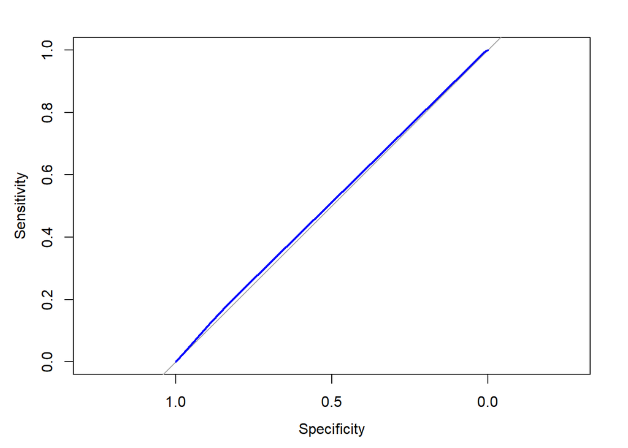

```r
# Load the pROC package
library(pROC)

# Create a ROC curve
ROC <- roc(donors$donated, donors$donation_prob)

# Plot the ROC curve
plot(ROC, col = "blue")
```

```r
# Calculate the area under the curve (AUC)
auc(ROC)
```

```
## Area under the curve: 0.5102
```

### Coding categorical features

Sometimes a dataset contains numeric values that represent a categorical feature.

In the `donors` dataset, `wealth_rating` uses numbers to indicate the donor’s wealth level:

- 0 = Unknown
- 1 = Low
- 2 = Medium
- 3 = High

This exercise illustrates how to prepare this type of categorical feature and then examines its impact on a logistic regression model.

**Instructions**

The dataframe `donors` is loaded in your workspace.

- Create a factor from the numeric `wealth_rating` with labels as shown above by passing the `factor()` function the column you want to convert, the individual levels, and the labels.
- Use `relevel()` to change the reference category to `Medium`. The first argument should be your `factor` column.
- Build a logistic regression model using the column `wealth_rating` to predict `donated` and display the result with `summary()`.

```r
# Convert the wealth rating to a factor
donors$wealth_rating <- factor(donors$wealth_rating, levels = c(0, 1, 2, 3), labels = c("Unknown", "Low", "Medium", "High"))

# Use relevel() to change reference category
donors$wealth_rating <- relevel(donors$wealth_rating, ref = "Medium")

model <- glm(donated ~ wealth_rating, data = donors, family = "binomial")

# See how our factor coding impacts the model
# summary(model)
stargazer::stargazer(model, type = "html", single.row = T)
```

|  | *Dependent variable:* |
| --- | --- |
|  | donated |
| wealth_ratingUnknown | -0.044 (0.042) |
| wealth_ratingLow | -0.052 (0.053) |
| wealth_ratingHigh | 0.048 (0.048) |
| Constant | -2.919*** (0.036) |
| Observations | 93,462 |
| Log Likelihood | -18,661.670 |
| Akaike Inf. Crit. | 37,331.340 |
| *Note:* | p<0.1; p<0.05; p<0.01 |

### Handling missing data

Some of the prospective donors have missing `age` data. Unfortunately, R will exclude any cases with `NA` values when building a regression model.

One workaround is to replace, or **impute**, the missing values with an estimated value. After doing so, you may also create a missing data indicator to model the possibility that cases with missing data are different in some way from those without.

**Instructions**

The dataframe `donors` is loaded in your workspace.

- Use `summary()` on `donors` to find the average `age` of prospects with non-missing data.
- Use `ifelse()` and the test `is.na(donor$age)` to impute the average (rounded to 2 decimal places) for cases with missing `age`.
- Create a binary dummy variable named `missing_age` indicating the presence of missing data using another `ifelse()` call and the same test.

```r
# Find the average age among non-missing values
summary(donors$age)
```

```
##    Min. 1st Qu.  Median    Mean 3rd Qu.    Max.    NA's
##    1.00   48.00   62.00   61.65   75.00   98.00   22546
```

```r
# Impute missing age values with mean(age)
donors$imputed_age <- ifelse(is.na(donors$age), 61.65, donors$age)

# Create missing value indicator for age
donors$missing_age <- ifelse(is.na(donors$age), 1, 0)
```

### Building a more sophisticated model

One of the best predictors of future giving is a history of recent, frequent, and large gifts. In marketing terms, this is known as R/F/M:

- Recency
- Frequency
- Money

Donors that haven given both recently and frequently may be especially likely to give again; in other words, the combined impact of recency and frequency may be greater than the sum of the separate effects.

Because these predictors together have a greater impact on the dependent variable, their joint effect must be modeled as an interaction.

**Instructions**

- Create a logistic regression model of `donated` as a function of `money` plus the interaction of `recency` and `frequency`. Use `*` to add the interaction term.
- Examine the model’s `summary()` to confirm the interaction effect was added.
- Save the model’s predicted probabilities as `rfm_prob`. Use the `predict()` function, and remember to set the `type` argument.
- Plot a ROC curve by using the function `roc()`. Remember, this function takes the column of outcomes and the vector of predictions.
- Compute the AUC for the new model with the function `auc()` and compare performance to the simpler model.

```r
# Build a recency, frequency, and money (RFM) model
rfm_model <- glm(formula = donated ~ money + recency * frequency, data = donors, family = "binomial")

# Summarize the RFM model to see how the parameters were coded
# summary(rfm_model)
stargazer::stargazer(rfm_model, type = "html", single.row = T)
```

|  | *Dependent variable:* |
| --- | --- |
|  | donated |
| moneyMEDIUM | 0.362*** (0.043) |
| recencyLAPSED | -0.867** (0.414) |
| frequencyINFREQUENT | -0.501*** (0.031) |
| recencyLAPSED:frequencyINFREQUENT | 1.018** (0.517) |
| Constant | -3.011*** (0.043) |
| Observations | 93,462 |
| Log Likelihood | -18,468.830 |
| Akaike Inf. Crit. | 36,947.650 |
| *Note:* | p<0.1; p<0.05; p<0.01 |

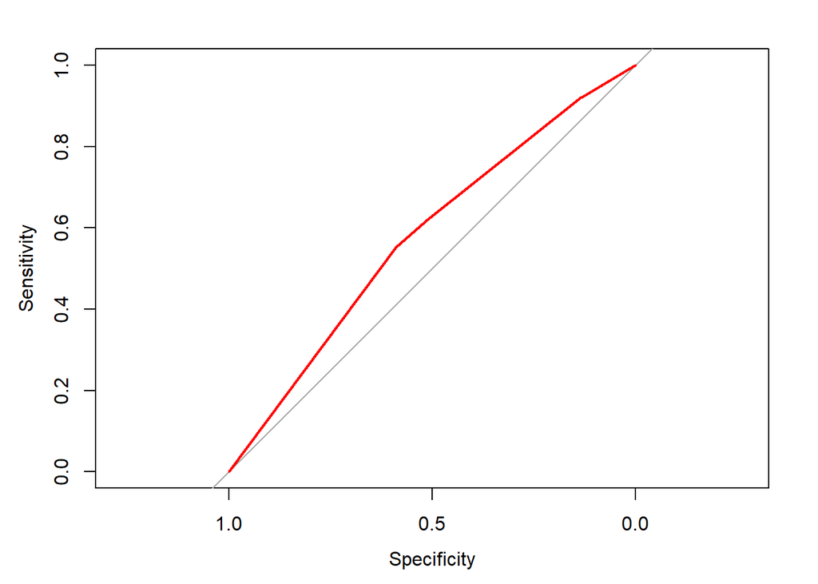

```r
# Compute predicted probabilities for the RFM model
rfm_prob <- predict(rfm_model, type = "response")

# Plot the ROC curve and find AUC for the new model
library(pROC)
ROC <- roc(donors$donated, rfm_prob)
plot(ROC, col = "red")
```

```r
auc(ROC)
```

Area under the curve: 0.5785

### Building a stepwise regression model

In the absence of subject-matter expertise, **stepwise regression** can assist with the search for the most important predictors of the outcome of interest.

In this exercise, you will use a forward stepwise approach to add predictors to the model one-by-one until no additional benefit is seen.

**Instructions**

- Use the R formula interface with `glm()` to specify the base model with no predictors. Set the explanatory variable equal to `1`.
- Use the R formula interface again with `glm()` to specify the model with all predictors.
- Apply `step()` to these models to perform forward stepwise regression. Set the first argument to `null_model` and set `direction = "forward"`. This might take a while (up to 10 or 15 seconds) as your computer has to fit quite a few different models to perform stepwise selection.
- Create a vector of predicted probabilities using the `predict()` function.
- Plot the ROC curve with `roc()` and `plot()` and compute the AUC of the stepwise model with `auc()`.

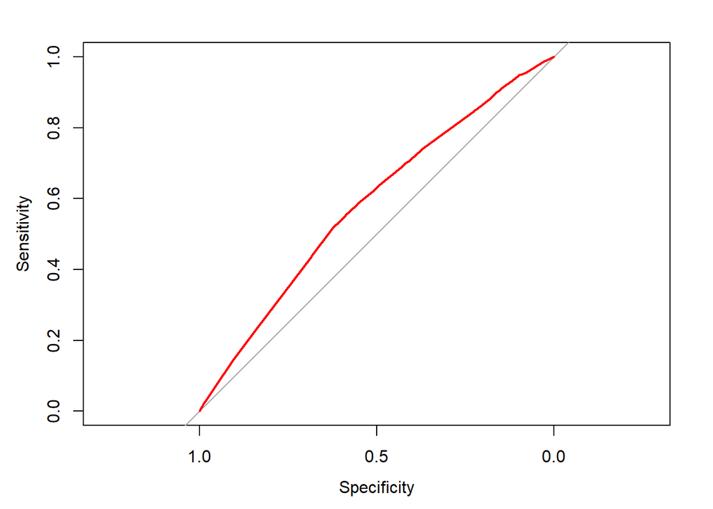

```r
# Specify a null model with no predictors
null_model <- glm(formula = donated ~ 1, data = donors, family = "binomial")

# Specify the full model using all of the potential predictors
full_model <- glm(formula = donated ~ ., data = donors, family = "binomial")

# Use a forward stepwise algorithm to build a parsimonious model
step_model <- step(null_model, scope = list(lower = null_model, upper = full_model), direction = "forward", trace = F)

# Estimate the stepwise donation probability
step_prob <- predict(step_model, type = "response")

# Plot the ROC of the stepwise model
library(pROC)
ROC <- roc(donors$donated, step_prob)
plot(ROC, col = "red")
```

```r
auc(ROC)
```

```
## Area under the curve: 0.5849
```

## Classification Trees

Slides

### Building a simple decision tree

The `loans` dataset contains 11,312 randomly-selected people who were applied for and later received loans from Lending Club, a US-based peer-to-peer lending company.

You will use a decision tree to try to learn patterns in the outcome of these loans (either repaid or default) based on the requested loan amount and credit score at the time of application.

Then, see how the tree’s predictions differ for an applicant with good credit versus one with bad credit.

**Instructions**

The dataset loans is already in your workspace.

- Load the `rpart` package.
- Fit a decision tree model with the function `rpart()`.
- Supply the R formula that specifies `outcome` as a function of `loan_amount` and `credit_score` as the first argument.
- Leave the `control` argument alone for now. (You’ll learn more about that later!)
- Use `predict()` with the resulting loan model to predict the `outcome` for the `good_credit` applicant. Use the `type` argument to predict the `"class"` of the outcome.
- Do the same for the `bad_credit` applicant.

```r
# Load the rpart package
library(rpart)

# Build a lending model predicting loan outcome versus loan amount and credit score
loan_model <- rpart(outcome ~ loan_amount + credit_score, data = loans, method = "class", control = rpart.control(cp = 0))

# Make a prediction for someone with good credit
predict(loan_model, good_credit, type = "class")
```

```
##      1
## repaid
## Levels: default repaid
```

```r
# Make a prediction for someone with bad credit
predict(loan_model, bad_credit, type = "class")
```

```
##       1
## default
## Levels: default repaid
```

### Visualizing classification trees

Due to government rules to prevent illegal discrimination, lenders are required to explain why a loan application was rejected.

The structure of classification trees can be depicted visually, which helps to understand how the tree makes its decisions.

**Instructions**

The model `loan_model` that you fit in the last exercise is in your workspace.

- Type `loan_model` to see a text representation of the classification tree.
- Load the `rpart.plot` package.
- Apply the `rpart.plot()` function to the loan model to visualize the tree.
- See how changing other plotting parameters impacts the visualization by running the supplied command.

```r
# Examine the loan_model object
loan_model
```

```
## n= 11312
##
## node), split, n, loss, yval, (yprob)
##       * denotes terminal node
##
##  1) root 11312 5654 repaid (0.4998232 0.5001768)
##    2) credit_score=AVERAGE,LOW 9490 4437 default (0.5324552 0.4675448)
##      4) credit_score=LOW 1667  631 default (0.6214757 0.3785243) *
##      5) credit_score=AVERAGE 7823 3806 default (0.5134859 0.4865141)
##       10) loan_amount=HIGH 2472 1079 default (0.5635113 0.4364887) *
##       11) loan_amount=LOW,MEDIUM 5351 2624 repaid (0.4903756 0.5096244)
##         22) loan_amount=LOW 1810  874 default (0.5171271 0.4828729) *
##         23) loan_amount=MEDIUM 3541 1688 repaid (0.4767015 0.5232985) *
##    3) credit_score=HIGH 1822  601 repaid (0.3298573 0.6701427) *
```

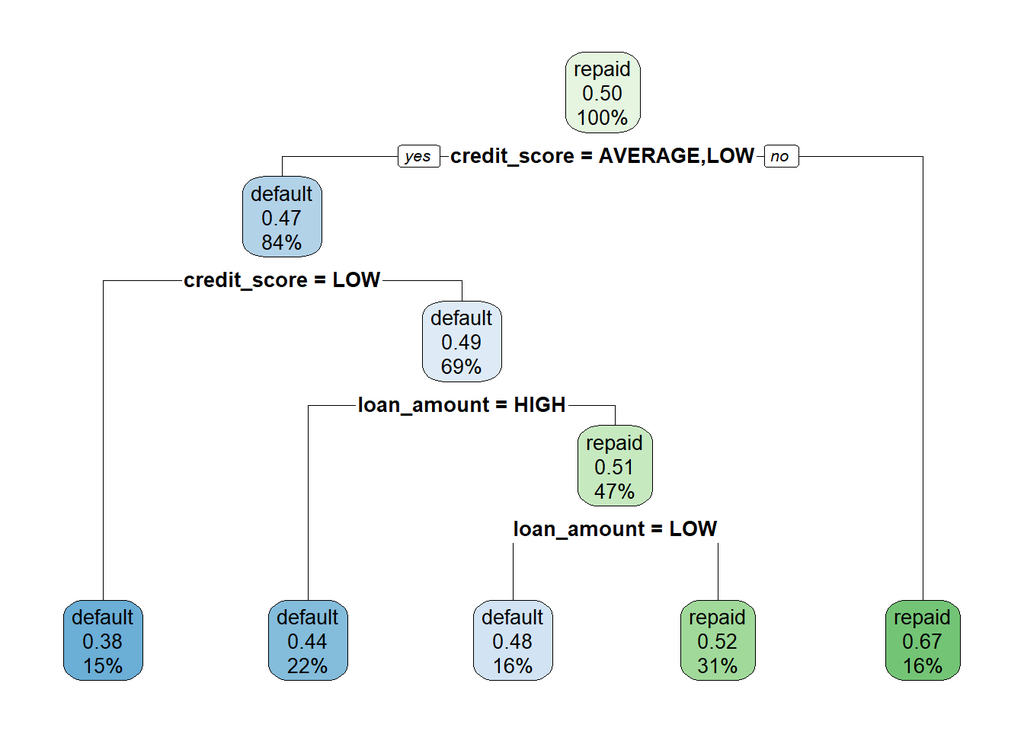

```r
# Load the rpart.plot package
library(rpart.plot)

# Plot the loan_model with default settings
rpart.plot(loan_model)
```

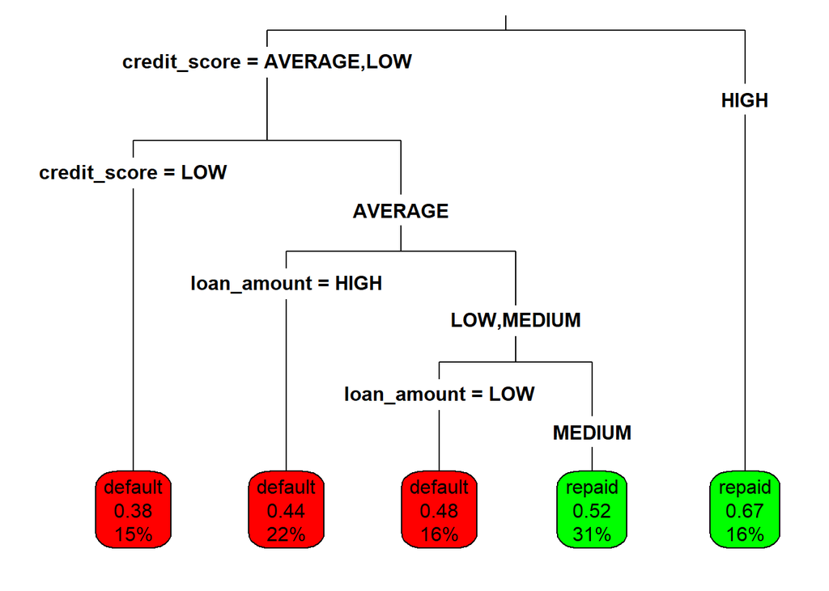

```r
# Plot the loan_model with customized settings
rpart.plot(loan_model, type = 3, box.palette = c("red", "green"), fallen.leaves = TRUE)
```

### Creating random test datasets

Before building a more sophisticated lending model, it is important to hold out a portion of the loan data to simulate how well it will predict the outcomes of future loan applicants.

As depicted in the following image, you can use 75% of the observations for training and 25% for testing the model.

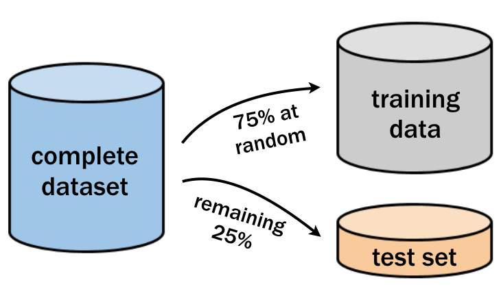

The `sample()` function can be used to generate a random sample of rows to include in the training set. Simply supply it the total number of observations and the number needed for training.

Use the resulting vector of row IDs to subset the loans into training and testing datasets.

**Instructions**

The dataset loans is in your workspace.

- Apply the `row()` function to determine how many observations are in the `loans` dataset, and the number needed for a 75% sample.
- Use the `sample()` function to create an integer vector of row IDs for the 75% sample. The first argument of `sample()` should be the number of rows in the data set, and the second is the number of rows you need in your training set.
- Subset the `loans` data using the row IDs to create the training dataset. Save this as `loans_train`.
- Subset loans again, but this time select all the rows that are not in `sample_rows`. Save this as `loans_test`

```r
set.seed(1)
# Determine the number of rows for training
nrow(loans) * 0.75
```

```
## [1] 8484
```

```r
# Create a random sample of row IDs
sample_rows <- sample(nrow(loans), nrow(loans) * 0.75)

# Create the training dataset
loans_train <- loans[sample_rows,]

# Create the test dataset
loans_test <- loans[-sample_rows,]
```

### Building and evaluating a larger tree

Previously, you created a simple decision tree that used the applicant’s credit score and requested loan amount to predict the loan outcome.

Lending Club has additional information about the applicants, such as home ownership status, length of employment, loan purpose, and past bankruptcies, that may be useful for making more accurate predictions.

Using all of the available applicant data, build a more sophisticated lending model using the random training dataset created previously. Then, use this model to make predictions on the testing dataset to estimate the performance of the model on future loan applications.

**Instructions**

- Use `rpart()` to build a loan model using the training dataset and all of the available predictors. Again, leave the `control` argument alone.
- Applying the `predict()` function to the testing dataset, create a vector of predicted outcomes. Don’t forget the `type` argument.
- Create a `table()` to compare the predicted values to the actual `outcome` values.
- Compute the accuracy of the predictions using the `mean()` function.

```r
# The 'rpart' package is loaded into the workspace
# The loans_train and loans_test datasets have been created

# Grow a tree using all of the available applicant data
loan_model <- rpart(outcome ~ ., data = loans_train, method = "class", control = rpart.control(cp = 0))

# Make predictions on the test dataset
loans_test$pred <- predict(loan_model, loans_test, type = "class")

# Examine the confusion matrix
table(loans_test$outcome, loans_test$pred)
```

```
##
##           default repaid
##   default     789    601
##   repaid      652    786
```

```r
# Compute the accuracy on the test dataset
mean(loans_test$outcome == loans_test$pred)
```

```
## [1] 0.5569307
```

### Preventing overgrown trees

The tree grown on the full set of applicant data grew to be extremely large and extremely complex, with hundreds of splits and leaf nodes containing only a handful of applicants. This tree would be almost impossible for a loan officer to interpret.

Using the **pre-pruning** methods for early stopping, you can prevent a tree from growing too large and complex. See how the `rpart` control options for maximum tree depth and minimum split count impact the resulting tree.

**Instructions**

- Add a `maxdepth` parameter to the `rpart.control()` object to set the maximum tree depth to six. Leave the parameter `cp = 0`. Pass the result of `rpart.control()` as the control parameter in your `rpart()` call.
- See how the test set accuracy of the simpler model compares to the original accuracy of 55.69%.
  - First create a vector of predictions using the `predict(`) function.
  - Compare the predictions to the actual outcomes and use `mean()` to calculate the accuracy.
- Add a `minsplit` parameter to the `rpart.control()` object to require 500 observations to split. Again, leave `cp = 0`.
- Again compare the accuracy of the simpler tree to the original.

```r
# The 'rpart' package is loaded into the workspace

# Grow a tree with maxdepth of 6
loan_model <- rpart(outcome ~ ., data = loans_train, method = "class", control = rpart.control(maxdepth = 6, cp = 0))

# Compute the accuracy of the simpler tree
loans_test$pred <- predict(loan_model, newdata = loans_test, type = "class")
mean(loans_test$outcome == loans_test$pred)
```

```
## [1] 0.5979491
```

```r
# Grow a tree with minsplit of 500
loan_model2 <- rpart(formula = outcome ~ ., data = loans_train, method = "class", control = rpart.control(cp = 0, minsplit = 500))

# Compute the accuracy of the simpler tree
loans_test$pred2 <- predict(loan_model2, newdata = loans_test, type = "class")
mean(loans_test$outcome == loans_test$pred2)
```

```
## [1] 0.5915842
```

### Creating a nicely pruned tree

Stopping a tree from growing all the way can lead it to ignore some aspects of the data or miss important trends it may have discovered later.

By using post-pruning, you can intentionally grow a large and complex then prune it to be smaller and more efficient later on.

In this exercise, you will have the opportunity to construct a visualization of the tree’s performance versus complexity, and use this information to prune the tree to an appropriate level.

**Instructions**

- Use all of the applicant variables and no pre-pruning to create an overly complex tree. Make sure to set `cp = 0` in `rpart.control()` to prevent pre-pruning.
- Create a complexity plot by using `plotcp()` on the model.
- Based on the complexity plot, prune the tree to a complexity of 0.0014 using the `prune()` function with the tree and the complexity parameter.
- Compare the accuracy of the pruned tree to the original accuracy of 55.69. To calculate the accuracy use the `predict()` and `mean()` functions.

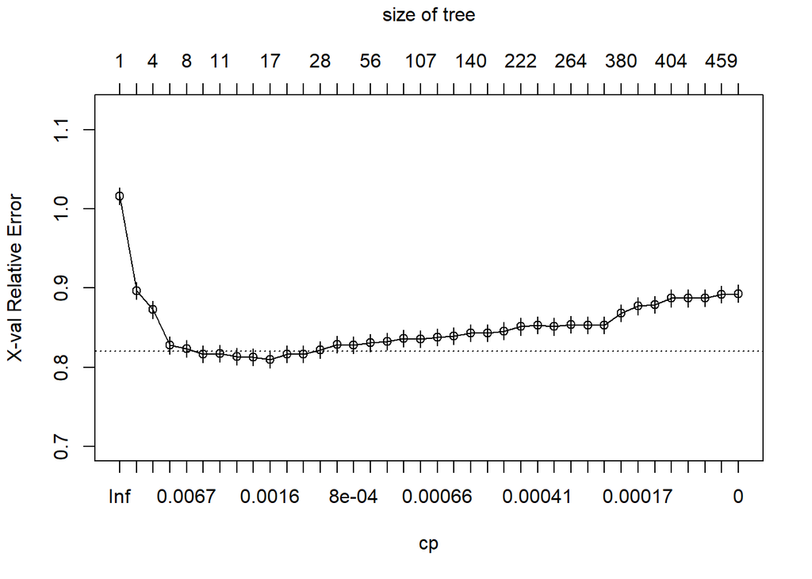

```r
# The 'rpart' package is loaded into the workspace

# Grow an overly complex tree
loan_model <- rpart(outcome ~ ., loans_train, method = "class", control = rpart.control(cp = 0))

# Examine the complexity plot
plotcp(loan_model)
```

```r
# Prune the tree
loan_model_pruned <- prune(loan_model, cp = 0.0014)

# Compute the accuracy of the pruned tree
loans_test$pred <- predict(loan_model_pruned, loans_test, type = "class")
mean(loans_test$pred == loans_test$outcome)
```

```
## [1] 0.6089109
```

### Building a random forest model

In spite of the fact that a forest can contain hundreds of trees, growing a decision tree forest is perhaps even easier than creating a single highly-tuned tree.

Using the `randomForest` package, build a random forest and see how it compares to the single trees you built previously.

Keep in mind that due to the random nature of the forest, the results may vary slightly each time you create the forest.

**Instructions**

- Load the `randomForest` package.
- Build a random forest model using all of the loan application variables. The `randomForest` function also uses the formula interface.
- Compute the accuracy of the random forest model to compare to the original tree’s accuracy of 55.69% using `predict()` and `mean()`.

```r
# Load the randomForest package
library(randomForest)
# Build a random forest model
loan_model <- randomForest(outcome ~ ., data = loans_train)

# Compute the accuracy of the random forest
loans_test$pred <- predict(loan_model, loans_test, type = "class")
mean(loans_test$pred == loans_test$outcome)
```

```
## [1] 0.5986563
```

# Supervised Learning: Regression

## What is Regression?

Slides

### Code a simple one-variable regression

For the first coding exercise, you’ll create a formula to define a one-variable modeling task, and then fit a linear model to the data. You are given the rates of male and female unemployment in the United States over several years ([Source](http://college.cengage.com/mathematics/brase/understandable_statistics/7e/students/datasets/slr/frames/slr02.html)).

The task is to predict the rate of female unemployment from the observed rate of male unemployment. The outcome is `female_unemployment`, and the input is `male_unemployment`.

The sign of the variable coefficient tells you whether the outcome increases (+) or decreases (-) as the variable increases.

Recall the calling interface for [`lm()`](https://www.rdocumentation.org/packages/stats/topics/lm) is:

`lm(formula, data = ___)`

**Instructions**

The data frame `unemployment` is in your workspace.

- Define a formula that expresses `female_unemployment` as a function of `male_unemployment`. Assign the formula to the variable `fmla` and print it.
- Then use `lm()` and `fmla` to fit a linear model to predict female unemployment from male unemployment using the data set `unemploymen`t.
- Print the model. Is the coefficent for male unemployment consistent with what you would expect? Does female unemployment increase as male unemployment does?

```r
# unemployment is loaded in the workspace
summary(unemployment)
```

```
##  male_unemployment female_unemployment
##  Min.   :2.900     Min.   :4.000
##  1st Qu.:4.900     1st Qu.:4.400
##  Median :6.000     Median :5.200
##  Mean   :5.954     Mean   :5.569
##  3rd Qu.:6.700     3rd Qu.:6.100
##  Max.   :9.800     Max.   :7.900
```

```r
# Define a formula to express female_unemployment as a function of male_unemployment
fmla <- as.formula("female_unemployment ~ male_unemployment")

# Print it
fmla
```

```
## female_unemployment ~ male_unemployment
```

```r
# Use the formula to fit a model: unemployment_model
unemployment_model <- lm(fmla, unemployment)
```

```r
# Print it
# unemployment_model
stargazer::stargazer(unemployment_model, type = "html", single.row = F)
```

|  | *Dependent variable:* |
| --- | --- |
|  | female_unemployment |
| male_unemployment | 0.695*** |
|  | (0.098) |
| Constant | 1.434** |
|  | (0.603) |
| Observations | 13 |
| R<sup>2</sup> | 0.821 |
| Adjusted R<sup>2</sup> | 0.805 |
| Residual Std. Error | 0.580 (df = 11) |
| F Statistic | 50.561*** (df = 1; 11) |
| *Note:* | p<0.1; p<0.05; p<0.01 |

### Examining a model

Let’s look at the model `unemployment_model` that you have just created. There are a variety of different ways to examine a model; each way provides different information. We will use [`summary()`](https://www.rdocumentation.org/packages/base/topics/summary), [`broom::glance()`](https://www.rdocumentation.org/packages/broom/topics/glance), and [`sigr::wrapFTest()`](https://www.rdocumentation.org/packages/sigr/topics/wrapFTest).

**Instructions**

The object `unemployment_model` is in your workspace.

- Print unemployment_model again. What information does it report?
- Call `summary(`) on `unemployment_model`. In addition to the coefficient values, you get standard errors on the coefficient estimates, and some goodness-of-fit metrics like R-squared.
- Call `glance()` on the model to see the performance metrics in an orderly data frame. Can you match the information from `summary()` to the columns of `glance()`?
- Now call `wrapFTest()` on the model to see the R-squared again.

```r
# broom and sigr are already loaded in your workspace
# Print unemployment_model
# unemployment_model

# Call summary() on unemployment_model to get more details
summary(unemployment_model)
```

```
##
## Call:
## lm(formula = fmla, data = unemployment)
##
## Residuals:
##      Min       1Q   Median       3Q      Max
## -0.77621 -0.34050 -0.09004  0.27911  1.31254
##
## Coefficients:
##                   Estimate Std. Error t value Pr(>|t|)
## (Intercept)        1.43411    0.60340   2.377   0.0367 *
## male_unemployment  0.69453    0.09767   7.111 1.97e-05 ***
## ---
## Signif. codes:  0 '***' 0.001 '**' 0.01 '*' 0.05 '.' 0.1 ' ' 1
##
## Residual standard error: 0.5803 on 11 degrees of freedom
## Multiple R-squared:  0.8213, Adjusted R-squared:  0.8051
## F-statistic: 50.56 on 1 and 11 DF,  p-value: 1.966e-05
```

```r
# Call glance() on unemployment_model to see the details in a tidier form
broom::glance(unemployment_model)
```

```
##   r.squared adj.r.squared     sigma statistic      p.value df    logLik
## 1 0.8213157     0.8050716 0.5802596  50.56108 1.965985e-05  2 -10.28471
##        AIC      BIC deviance df.residual
## 1 26.56943 28.26428 3.703714          11
```

```r
# Call wrapFTest() on unemployment_model to see the most relevant details
sigr::wrapFTest(unemployment_model)
```

```
## [1] "F Test summary: (R2=0.821, F(1,11)=50.6, p=2e-05)."
```

### Predicting from the unemployment model

In this exercise, you will use your unemployment model `unemployment_model` to make predictions from the `unemployment` data, and compare predicted female unemployment rates to the actual observed female unemployment rates on the training data, `unemployment`. You will also use your model to predict on the new data in `newrates`, which consists of only one observation, where male unemployment is 5%.

The [`predict()`](https://www.rdocumentation.org/packages/stats/topics/predict.lm) interface for `lm` models takes the form

`predict(model, newdata)`

You will use the `ggplot2` package to make the plots, so you will add the prediction column to the `unemployment` data frame. You will plot outcome versus prediction, and compare them to the line that represents perfect predictions (that is when the outcome is equal to the predicted value).

The `ggplot2` command to plot a scatterplot of `dframe$outcome` versus `dframe$pred` (`pred` on the x axis, `outcome` on the y axis), along with a blue line where `outcome == pred` is as follows:

```
ggplot(dframe, aes(x = pred, y = outcome)) +
       geom_point() +
       geom_abline(color = "blue")
```

**Instructions**

The objects `unemployment`, `unemployment_model` and `newrates` are in your workspace.

- Use `predict()` to predict female unemployment rates from the `unemployment` data. Assign it to a new column: prediction.
- Use the `library()` command to load the `ggplot2` package.
- Use `ggplot()` to compare the predictions to actual unemployment rates. Put the predictions on the x axis. How close are the results to the line of perfect prediction?
- Use the data frame `newrates` to predict expected female unemployment rate when male unemployment is 5%. Assign the answer to the variable `pred` and print it.

```r
# unemployment is in your workspace
# summary(unemployment)

# newrates is in your workspace
newrates
```

```
##   male_unemployment
## 1                 5
```

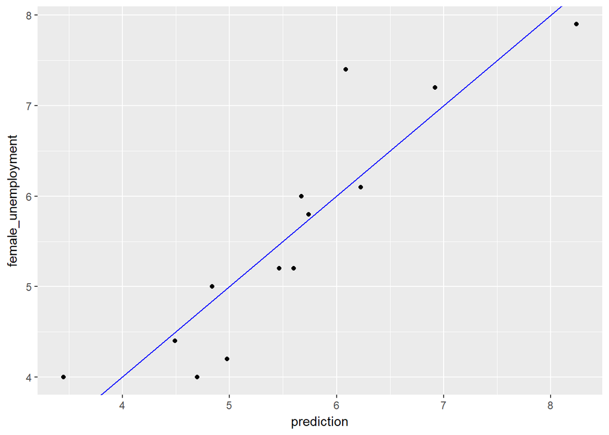

```r
# Predict female unemployment in the unemployment data set
unemployment$prediction <-  predict(unemployment_model)

# load the ggplot2 package
library(ggplot2)

# Make a plot to compare predictions to actual (prediction on x axis).
ggplot(unemployment, aes(x = prediction, y = female_unemployment)) +
  geom_point() +
  geom_abline(color = "blue")
```

```r
# Predict female unemployment rate when male unemployment is 5%
pred <- predict(unemployment_model, newrates)
# Print it
pred
```

```
##        1
## 4.906757
```

### Multivariate linear regression (Part 1)

In this exercise, you will work with the blood pressure dataset ([Source](http://college.cengage.com/mathematics/brase/understandable_statistics/7e/students/datasets/mlr/frames/frame.html)), and model `blood_pressure` as a function of `weight` and `age`.

**Instructions**

```r
bloodpressure <- readRDS("Data/2Regression/bloodpressure.rds")
```

The data frame bloodpressure is in the workspace.

- Define a formula that expresses `blood_pressure` explicitly as a function of `age` and `weight`. Assign the formula to the variable `fmla` and print it.
- Use `fmla` to fit a linear model to predict `blood_pressure` from `age` and `weight` in the data set `bloodpressure`. Call the model `bloodpressure_model`.
- Print the model and call `summary()` on it. Does blood pressure increase or decrease with age? With weight?

```r
# bloodpressure is in the workspace
# summary(bloodpressure)

# Create the formula and print it
fmla <- as.formula("blood_pressure ~ weight + age")
fmla
```

```
## blood_pressure ~ weight + age
```

```r
# Fit the model: bloodpressure_model
bloodpressure_model <- lm(fmla, bloodpressure)
```

```r
# Print bloodpressure_model and call summary()
# bloodpressure_model
# summary(bloodpressure_model)
stargazer::stargazer(bloodpressure_model, type = "html", single.row = T)
```

|  | *Dependent variable:* |
| --- | --- |
|  | blood_pressure |
| weight | 0.335** (0.131) |
| age | 0.861*** (0.248) |
| Constant | 30.994** (11.944) |
| Observations | 11 |
| R<sup>2</sup> | 0.977 |
| Adjusted R<sup>2</sup> | 0.971 |
| Residual Std. Error | 2.318 (df = 8) |
| F Statistic | 168.765*** (df = 2; 8) |
| *Note:* | p<0.1; p<0.05; p<0.01 |

### Multivariate linear regression (Part 2)

Now you will make predictions using the blood pressure model `bloodpressure_model` that you fit in the previous exercise.

You will also compare the predictions to outcomes graphically. `ggplot2` is already loaded in your workspace. Recall the plot command takes the form:

```
ggplot(dframe, aes(x = pred, y = outcome)) +
     geom_point() +
     geom_abline(color = "blue")
```

**Instructions**

The objects `bloodpressure` and `bloodpressure_model` are in the workspace.

- Use `predict()` to predict blood pressure in the `bloodpressure` dataset. Assign the predictions to the column prediction.
- Graphically compare the predictions to actual blood pressures. Put predictions on the x axis. How close are the results to the line of perfect prediction?

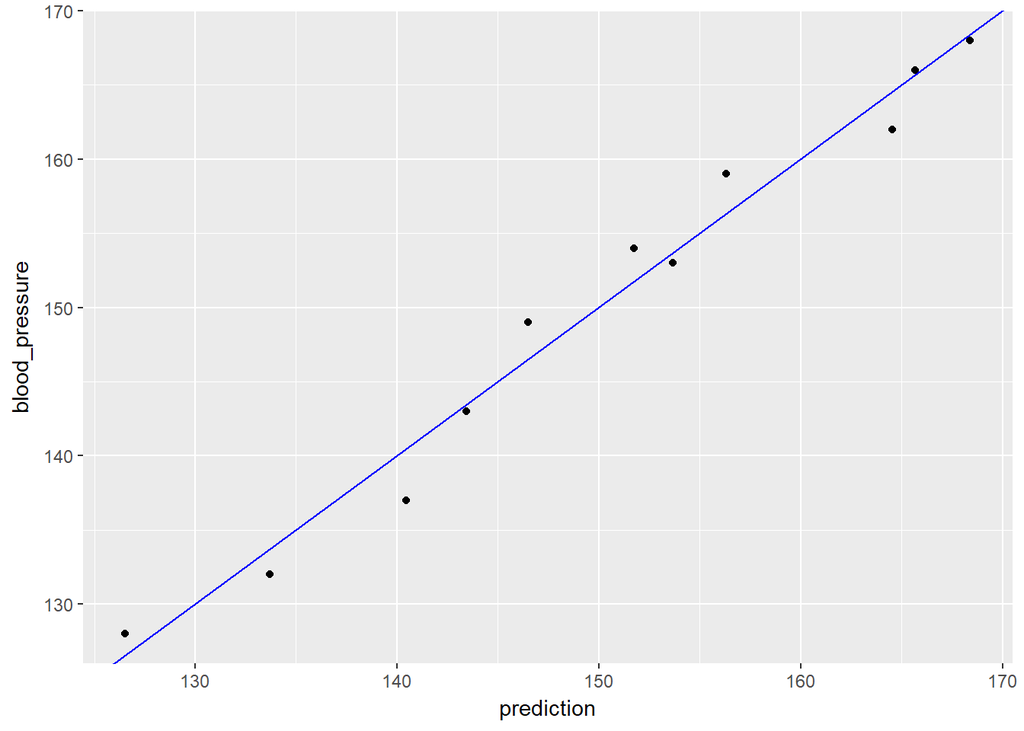

```r
# bloodpressure is in your workspace
# summary(bloodpressure)

# bloodpressure_model is in your workspace
# bloodpressure_model

# predict blood pressure using bloodpressure_model :prediction
bloodpressure$prediction <- predict(bloodpressure_model)

# plot the results
ggplot(bloodpressure, aes(x = prediction, y = blood_pressure)) +
    geom_point() +
    geom_abline(color = "blue")
```

## Training and Evaluating Regression Models

### Graphically evaluate the unemployment model

In this exercise you will graphically evaluate the unemployment model, `unemployment_model`, that you fit to the `unemployment` data in the previous chapter. Recall that the model predicts `female_unemployment` from `male_unemployment`.

You will plot the model’s predictions against the actual `female_unemployment`; recall the command is of the form

```
ggplot(dframe, aes(x = pred, y = outcome)) +
       geom_point() +
       geom_abline()
```

Then you will calculate the residuals:

```
residuals <- actual outcome - predicted outcome
```

**Instructions**

The data frame`unemployment` and model `unemployment_model` are available in the workspace.

- Use `predict()` to get the model predictions and add them to `unemployment` as the column predictions.
- Plot predictions (on the x-axis) versus actual female unemployment rates. Are the predictions near the x=yx=y line?
- Calculate the residuals between the predictions and actual unemployment rates. Add these residuals to `unemployment` as the column `residuals`.
- Fill in the blanks to plot predictions (on the x-axis) versus residuals (on the y-axis). This gives you a different view of the model’s predictions as compared to ground truth.

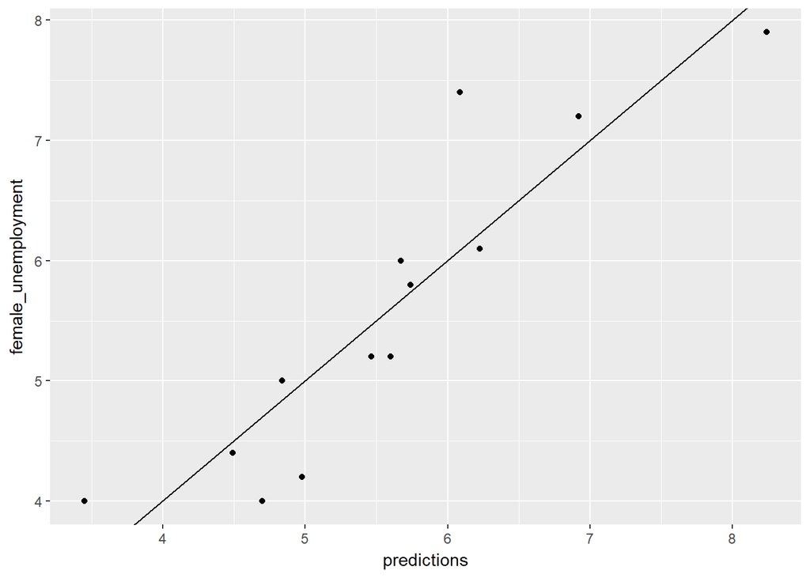

```r
# unemployment is in the workspace
# summary(unemployment)

# unemployment_model is in the workspace
# summary(unemployment_model)

# Make predictions from the model
unemployment$predictions <- predict(unemployment_model)

# Fill in the blanks to plot predictions (on x-axis) versus the female_unemployment rates
ggplot(unemployment, aes(x = predictions, y = female_unemployment)) +
geom_point()+
geom_abline()
```

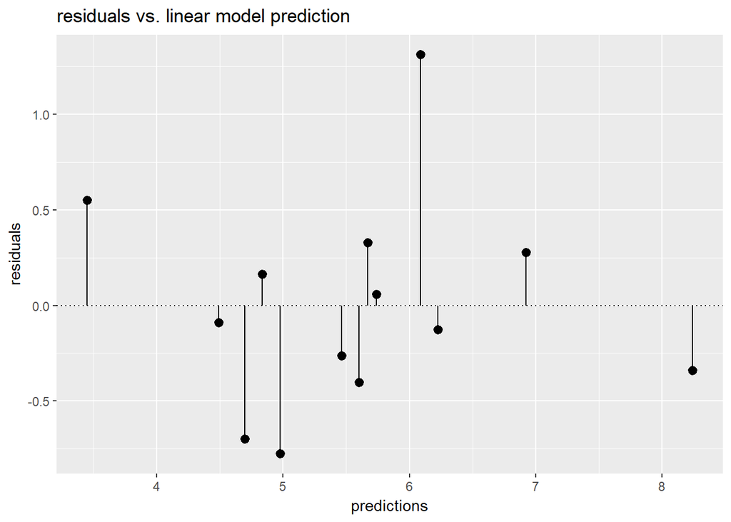

```r
# Calculate residuals
unemployment$residuals <- unemployment$female_unemployment - unemployment$predictions

# Fill in the blanks to plot predictions (on x-axis) versus the residuals
ggplot(unemployment, aes(x = predictions, y = residuals)) +
  geom_pointrange(aes(ymin = 0, ymax = residuals)) +
  geom_hline(yintercept = 0, linetype = 3) +
  ggtitle("residuals vs. linear model prediction")
```

### The gain curve to evaluate the unemployment model

In the previous exercise you made predictions about `female_unemployment` and visualized the predictions and the residuals. Now, you will also plot the gain curve of the `unemployment_model`’s predictions against actual `female_unemployment` using the [`WVPlots::GainCurvePlot()`](https://www.rdocumentation.org/packages/WVPlots/topics/GainCurvePlot) function.

For situations where order is more important than exact values, the gain curve helps you check if the model’s predictions sort in the same order as the true outcome.

Calls to the function `GainCurvePlot()` look like:

```
GainCurvePlot(frame, xvar, truthvar, title)
```

where

- frame is a data frame
- xvar and truthvar are strings naming the prediction and actual outcome columns of frame
- title is the title of the plot

When the predictions sort in exactly the same order, the relative Gini coefficient is 1. When the model sorts poorly, the relative Gini coefficient is close to zero, or even negative.

**Instructions**

The data frame `unemployment` and the model `nemployment_model` are in the workspace.

- Load the package `WVPlots`.
- Plot the gain curve. Give the plot the title “Unemployment model”. Do the model’s predictions sort correctly?

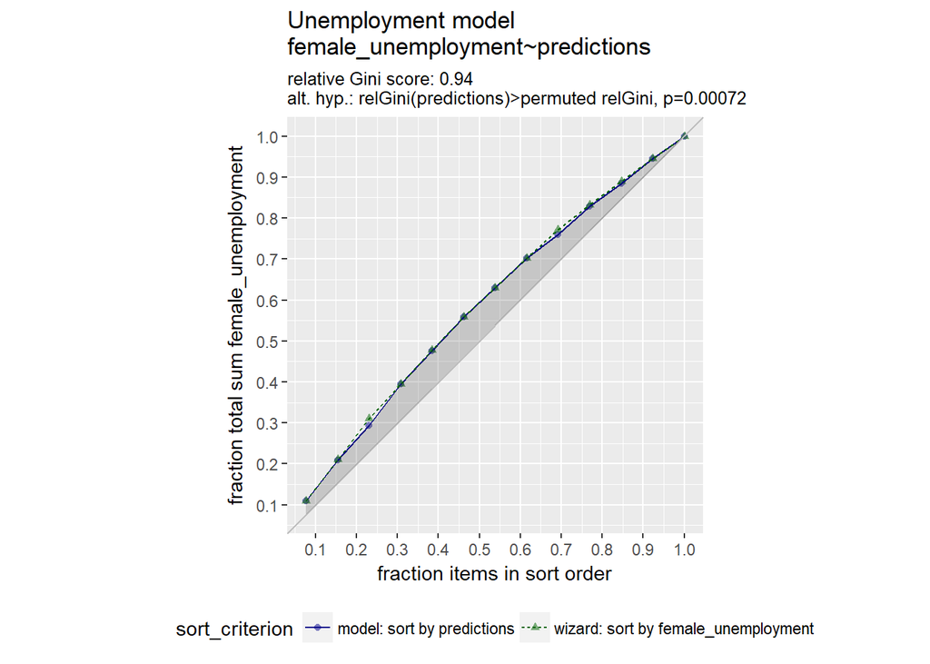

```r
# unemployment is in the workspace (with predictions)
# summary(unemployment)

# unemployment_model is in the workspace
# summary(unemployment_model)

# Load the package WVPlots
library(WVPlots)

# Plot the Gain Curve
GainCurvePlot(unemployment, "predictions", "female_unemployment", "Unemployment model")
```

### Calculate RMSE

In this exercise you will calculate the RMSE of your unemployment model. In the previous coding exercises, you added two columns to the unemployment dataset:

the model’s predictions (predictions column) the residuals between the predictions and the outcome (residuals column) You can calculate the RMSE from a vector of residuals, resres, as:

$$RMSE = \sqrt{\mathrm{mean}{(res^2)}}$$

$$RMSE = \sqrt{\frac{1}{n}\sum_{i = 1}^n{(pred_i-obs_i)^2}}$$

You want RMSE to be small. How small is “small”? One heuristic is to compare the RMSE to the standard deviation of the outcome. With a good model, the RMSE should be smaller.

**Instructions**

The data frame `unemployment` is in your workspace.

- Review the `unemployment` data from the previous exercise.
- For convenience, assign the residuals column from `unemployment` to the variable `res`.
- Calculate RMSE: square `res`, take its mean, and then square root it. Assign this to the variable `rmse` and print it.
  - Tip: you can do this in one step by wrapping the assignment in parentheses: `(rmse <- ___)`
- Calculate the standard deviation of `female_unemployment` and assign it to the variable `sd_unemployment`. Print it. *How does the rmse of the model compare to the standard deviation of the data?*

```r
# unemployment is in the workspace
# summary(unemployment)

# For convenience put the residuals in the variable res
res <- unemployment$residuals

# Calculate RMSE, assign it to the variable rmse and print it
(rmse <- sqrt(mean(res^2)))
```

```
## [1] 0.5337612
```

```r
# Calculate the standard deviation of female_unemployment and print it
(sd_unemployment <- sd(unemployment$female_unemployment))
```

```
## [1] 1.314271
```

### Calculate R-Squared

Now that you’ve calculated the RMSE of your model’s predictions, you will examine how well the model fits the data: that is, how much variance does it explain. You can do this using $R^2$.

Suppose $y$ is the true outcome, $p$ is the prediction from the model, and $res=y−p$ are the residuals of the predictions.

Then the total sum of squares $tss$ (“total variance”) of the data is:

$$tss = \sum{(y-\bar{y})}^2$$

where $\bar{y}$ is the mean value of $y$.

The residual sum of squared errors of the model, $rss$ is:

$$rss = \sum{res^2}$$

$R^2$ (R-Squared), the “variance explained” by the model, is then:

$$R^2 = 1-\frac{rss}{tss}$$

After you calculate $R^2$, you will compare what you computed with the $R^2$ reported by [`glance()`](https://www.rdocumentation.org/packages/broom/topics/glance). `glance()` returns a one-row data frame; for a linear regression model, one of the columns returned is the $R^2$ of the model on the training data.

The data frame `unemployment` is in your workspace, with the columns `predictions` and `residuals` that you calculated in a previous exercise.

**Instructions**

The data frame `unemployment` and the model `unemployment_model` are in the workspace.

- Calculate the mean `female_unemployment` and assign it to the variable `fe_mean`.
- Calculate the total sum of squares and assign it to the variable `tss`.
- Calculate the residual sum of squares and assign it to the variable `rss`.
- Calculate $R^2$. Is it a good fit ($R^2$ near 1)?
- Use `glance()` to get $R^2$ from the model. *Is it the same as what you calculated?*

```r
# unemployment is in your workspace
# summary(unemployment)

# unemployment_model is in the workspace
# summary(unemployment_model)

# Calculate mean female_unemployment: fe_mean. Print it
(fe_mean <- mean(unemployment$female_unemployment))
```

```
## [1] 5.569231
```

```r
# Calculate total sum of squares: tss. Print it
(tss <- sum((unemployment$female_unemployment - fe_mean)^2))
```

```
## [1] 20.72769
```

```r
# Calculate residual sum of squares: rss. Print it
(rss <- sum(unemployment$residuals^2))
```

```
## [1] 3.703714
```

```r
# Calculate R-squared: rsq. Print it. Is it a good fit?
(rsq <- 1-(rss/tss))
```

```
## [1] 0.8213157
```

```r
# Get R-squared from glance. Print it
(rsq_glance <- broom::glance(unemployment_model)$r.squared)
```

```
## [1] 0.8213157
```

### Correlation and R-squared

The linear correlation of two variables, $x$ and $y$, measures the strength of the linear relationship between them. When $x$ and $y$ are respectively:

- the outcomes of a regression model that minimizes squared-error (like linear regression) and
- the true outcomes of the *training data*,
- then the square of the correlation is the same as $R^2$. You will verify that in this exercise.

**Instructions**

- Use [`cor()`](https://www.rdocumentation.org/packages/stats/topics/cor) to get the correlation between the predictions and female unemployment. Assign it to the variable `rho` and print it. Make sure you use Pearson correlation (the default).
- Square `rho` and assign it to `rho2`. Print it.
- Compare `rho2` to $R^2$ from the model (using `glance()`). Is it the same?

```r
# unemployment is in your workspace
# summary(unemployment)

# unemployment_model is in the workspace
# summary(unemployment_model)

# Get the correlation between the prediction and true outcome: rho and print it
(rho <- cor(unemployment$predictions, unemployment$female_unemployment))
```

```
## [1] 0.9062647
```

```r
# Square rho: rho2 and print it
(rho2 <- rho^2)
```

```
## [1] 0.8213157
```

```r
# Get R-squared from glance and print it
(rsq_glance <- broom::glance(unemployment_model)$r.squared)
```

```
## [1] 0.8213157
```

### Generating a random test/train split

For the next several exercises you will use the `mpg` data from the package `ggplot2`. The data describes the characteristics of several makes and models of cars from different years. The goal is to predict city fuel efficiency from highway fuel efficiency.

In this exercise, you will split `mpg` into a training set `mpg_train` (75% of the data) and a test set `mpg_test` (25% of the data). One way to do this is to generate a column of uniform random numbers between 0 and 1, using the function [`runif()`](https://www.rdocumentation.org/packages/stats/topics/Uniform).

If you have a data set dframe of size $N$, and you want a random subset of approximately size $100∗X$% of $N$ (where $X$ is between 0 and 1), then:

1. Generate a vector of uniform random numbers: `gp = runif(N)`.
2. `dframe[gp < X,]` will be about the right size.
3. `dframe[gp >= X,]` will be the complement.

**Instructions**

The data frame `mpg` is in the workspace.

- Use the function [`nrow`](https://www.rdocumentation.org/packages/base/topics/nrow) to get the number of rows in the data frame `mpg`. Assign this count to the variable `N` and print it.
- Calculate about how many rows 75% of `N` should be. Assign it to the variable `target` and print it.
- Use `runif()` to generate a vector of `N` uniform random numbers, called `gp`.
- Use `gp` to split `mpg` into `mpg_train` and `mpg_test` (with `mpg_train` containing approximately 75% of the data).
- Use `nrow()` to check the size of `mpg_train` and `mpg_test`. Are they about the right size?

```r
# mpg is in the workspace
summary(mpg)
```

```
##  manufacturer          model               displ            year
##  Length:234         Length:234         Min.   :1.600   Min.   :1999
##  Class :character   Class :character   1st Qu.:2.400   1st Qu.:1999
##  Mode  :character   Mode  :character   Median :3.300   Median :2004
##                                        Mean   :3.472   Mean   :2004
##                                        3rd Qu.:4.600   3rd Qu.:2008
##                                        Max.   :7.000   Max.   :2008
##       cyl           trans               drv                 cty
##  Min.   :4.000   Length:234         Length:234         Min.   : 9.00
##  1st Qu.:4.000   Class :character   Class :character   1st Qu.:14.00
##  Median :6.000   Mode  :character   Mode  :character   Median :17.00
##  Mean   :5.889                                         Mean   :16.86
##  3rd Qu.:8.000                                         3rd Qu.:19.00
##  Max.   :8.000                                         Max.   :35.00
##       hwy             fl               class
##  Min.   :12.00   Length:234         Length:234
##  1st Qu.:18.00   Class :character   Class :character
##  Median :24.00   Mode  :character   Mode  :character
##  Mean   :23.44
##  3rd Qu.:27.00
##  Max.   :44.00
```

```r
dim(mpg)
```

```
## [1] 234  11
```

```r
# Use nrow to get the number of rows in mpg (N) and print it
(N <- nrow(mpg))
```

```
## [1] 234
```

```r
# Calculate how many rows 75% of N should be and print it
# Hint: use round() to get an integer
(target <- round(N*.75))
```

```
## [1] 176
```

```r
# Create the vector of N uniform random variables: gp
set.seed(1)
gp <- runif(N)

# Use gp to create the training set: mpg_train (75% of data) and mpg_test (25% of data)
mpg_train <- mpg[gp < 0.75,]
mpg_test <- mpg[gp >= 0.75,]

# Use nrow() to examine mpg_train and mpg_test
nrow(mpg_train)
```

```
## [1] 177
```

```r
nrow(mpg_test)
```

```
## [1] 57
```

### Train a model using test/train split

Now that you have split the `mpg` dataset into `mpg_train` and `mpg_test`, you will use `mpg_train` to train a model to predict city fuel efficiency (`cty`) from highway fuel efficiency (`hwy`).

**Instructions**

The data frame `mpg_train` is in the workspace.

- Create a formula `fmla` that expresses the relationship `cty` as a function of `hwy`. Print it.
- Train a model `mpg_model` on `mpg_train` to predict `cty` from `hwy` using `fmla` and `lm()`.
- Use `summary()` to examine the model.

```r
# mpg_train is in the workspace
summary(mpg_train)
```

```
##  manufacturer          model               displ            year
##  Length:177         Length:177         Min.   :1.600   Min.   :1999
##  Class :character   Class :character   1st Qu.:2.400   1st Qu.:1999
##  Mode  :character   Mode  :character   Median :3.300   Median :1999
##                                        Mean   :3.498   Mean   :2003
##                                        3rd Qu.:4.600   3rd Qu.:2008
##                                        Max.   :7.000   Max.   :2008
##       cyl           trans               drv                 cty
##  Min.   :4.000   Length:177         Length:177         Min.   : 9.00
##  1st Qu.:4.000   Class :character   Class :character   1st Qu.:14.00
##  Median :6.000   Mode  :character   Mode  :character   Median :16.00
##  Mean   :5.932                                         Mean   :16.72
##  3rd Qu.:8.000                                         3rd Qu.:19.00
##  Max.   :8.000                                         Max.   :35.00
##       hwy             fl               class
##  Min.   :12.00   Length:177         Length:177
##  1st Qu.:17.00   Class :character   Class :character
##  Median :24.00   Mode  :character   Mode  :character
##  Mean   :23.28
##  3rd Qu.:27.00
##  Max.   :44.00
```

```r
# Create a formula to express cty as a function of hwy: fmla and print it.
(fmla <- as.formula("cty ~ hwy"))
```

```
## cty ~ hwy
```

```r
# Now use lm() to build a model mpg_model from mpg_train that predicts cty from hwy
mpg_model <- lm(fmla, mpg_train)
```

```r
# Use summary() to examine the model
# summary(mpg_model)

stargazer::stargazer(mpg_model, type = "html", single.row = T)
```

|  | *Dependent variable:* |
| --- | --- |
|  | cty |
| hwy | 0.672*** (0.016) |
| Constant | 1.070*** (0.392) |
| Observations | 177 |
| R<sup>2</sup> | 0.907 |
| Adjusted R<sup>2</sup> | 0.906 |
| Residual Std. Error | 1.300 (df = 175) |
| F Statistic | 1,702.863*** (df = 1; 175) |
| *Note:* | p<0.1; p<0.05; p<0.01 |

### Evaluate a model using test/train split

Now you will test the model `mpg_model` on the test data, `mpg_test`. Functions `rmse()` and `r_squared()` to calculate RMSE and R-squared have been provided for convenience:

```
rmse(predcol, ycol)
r_squared(predcol, ycol)
```

where:

- `predcol`: The predicted values
- `ycol`: The actual outcome

You will also plot the predictions vs. the outcome.

Generally, model performance is better on the training data than the test data (though sometimes the test set “gets lucky”). A slight difference in performance is okay; if the performance on training is significantly better, there is a problem.

**Instructions**

The data frames `mpg_train` and `mpg_test`, and the model `mpg_model` are in the workspace, along with the functions `rmse()` and `r_squared()`.

- Predict city fuel efficiency from `hwy` on the `mpg_train` data. Assign the predictions to the column `pred`.
- Predict city fuel efficiency from `hwy` on the `mpg_test` data. Assign the predictions to the column `pred`.
- Use `rmse()` to evaluate rmse for both the test and training sets. Compare. Are the performances similar?
- Do the same with `r_squared()`. Are the performances similar?
- Use `ggplot2` to plot the predictions against `cty` on the test data.

```r
# Examine the objects in the workspace
# ls.str()

# predict cty from hwy for the training set
mpg_train$pred <- predict(mpg_model, mpg_train)

# predict cty from hwy for the test set
mpg_test$pred <- predict(mpg_model, mpg_test)

# Evaluate the rmse on both training and test data and print them
(rmse_train <- rmse(mpg_train$pred, mpg_train$cty))
```

```
## [1] 1.292196
```

```r
(rmse_test <- rmse(mpg_test$pred, mpg_test$cty))
```

```
## [1] 1.103904
```

```r
# Evaluate the r-squared on both training and test data.and print them
(rsq_train <- r_squared(mpg_train$pred, mpg_train$cty))
```

```
## [1] 0.9068089
```

```r
(rsq_test <- r_squared(mpg_test$pred, mpg_test$cty))
```

```
## [1] 0.9329215
```

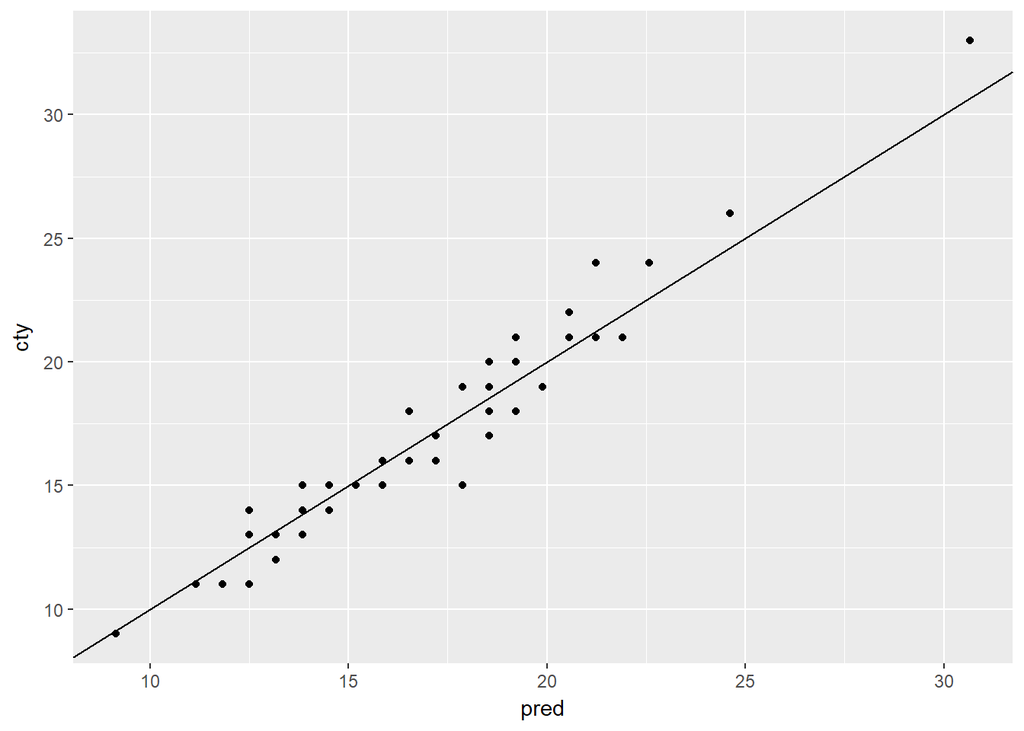

```r
# Plot the predictions (on the x-axis) against the outcome (cty) on the test data
ggplot(mpg_test, aes(x = pred, y = cty)) +
  geom_point() +
  geom_abline()
```

### Create a cross validation plan

There are several ways to implement an n-fold cross validation plan. In this exercise you will create such a plan using [`vtreat::kWayCrossValidation()`](https://www.rdocumentation.org/packages/vtreat/versions/topics/kWayCrossValidation), and examine it.

`kWayCrossValidation()` creates a cross validation plan with the following call:

```
splitPlan <- kWayCrossValidation(nRows, nSplits, dframe, y)
```

where `nRows` is the number of rows of data to be split, and `nSplits` is the desired number of cross-validation folds.

Strictly speaking, `dframe` and `y` aren’t used by `kWayCrossValidation`; they are there for compatibility with other `vtreat` data partitioning functions. You can set them both to `NUL`L.

The resulting `splitPlan` is a list of `nSplits` elements; each element contains two vectors:

- `train`: the indices of `dframe` that will form the training set
- `app`: the indices of `dframe` that will form the test (or application) set

In this exercise you will create a 3-fold cross-validation plan for the data set `mpg`.

**Instructions**

- Load the package `vtreat`.
- Get the number of rows in `mpg` and assign it to the variable `nRows`.
- Call `kWayCrossValidation` to create a 3-fold cross validation plan and assign it to the variable `splitPlan`.
- You can set the last two arguments of the function to `NULL`.
- Call `str()` to examine the structure of `splitPlan`.

```r
# Load the package vtreat
library(vtreat)

# mpg is in the workspace
# summary(mpg)

# Get the number of rows in mpg
nRows <- nrow(mpg)

# Implement the 3-fold cross-fold plan with vtreat
splitPlan <- kWayCrossValidation(nRows, 3, dframe = NULL, y = NULL)

# Examine the split plan
str(splitPlan)
```

```
## List of 3
##  $ :List of 2
##   ..$ train: int [1:156] 1 4 5 6 7 8 10 12 13 15 ...
##   ..$ app  : int [1:78] 160 104 206 48 102 203 229 106 109 162 ...
##  $ :List of 2
##   ..$ train: int [1:156] 2 3 6 9 11 14 16 17 18 19 ...
##   ..$ app  : int [1:78] 92 129 70 33 96 207 220 24 79 66 ...
##  $ :List of 2
##   ..$ train: int [1:156] 1 2 3 4 5 7 8 9 10 11 ...
##   ..$ app  : int [1:78] 161 99 132 93 30 167 130 53 196 58 ...
##  - attr(*, "splitmethod")= chr "kwaycross"
```

### Evaluate a modeling procedure using n-fold cross-validation

In this exercise you will use `splitPlan`, the 3-fold cross validation plan from the previous exercise, to make predictions from a model that predicts `mpg$cty` from `mpg$hwy`.

If `dframe` is the training data, then one way to add a column of cross-validation predictions to the frame is as follows:

```
# Initialize a column of the appropriate length
dframe$pred.cv <- 0

# k is the number of folds
# splitPlan is the cross validation plan

for(i in 1:k) {
  # Get the ith split
  split <- splitPlan[[i]]

  # Build a model on the training data
  # from this split
  # (lm, in this case)
  model <- lm(fmla, data = dframe[split$train,])

  # make predictions on the
  # application data from this split
  dframe$pred.cv[split$app] <- predict(model, newdata = dframe[split$app,])
}
```

Cross-validation predicts how well a model built from all the data will perform on new data. As with the test/train split, for a good modeling procedure, cross-validation performance and training performance should be close.

**Instructions**

The data frame mpg, the cross validation plan splitPlan, and the function to calculate RMSE (rmse()) from one of the previous exercises is available in your workspace.

- Run the 3-fold cross validation plan from `splitPlan` and put the predictions in the column `mpg$pred.cv`.
- Use `lm()` and the formula `cty ~ hwy`.
- Create a linear regression model on all the `mpg` data (formula `cty ~ hwy`) and assign the predictions to `mpg$pred`.
- Use `rmse()` to get the root mean squared error of the predictions from the full model (`mpg$pred`). *Recall that `rmse()` takes two arguments, the predicted values, and the actual outcome.*
- Get the root mean squared error of the cross-validation predictions. Are the two values about the same?

```r
# mpg is in the workspace
# summary(mpg)

# splitPlan is in the workspace
# str(splitPlan)

# Run the 3-fold cross validation plan from splitPlan
k <- 3 # Number of folds
mpg$pred.cv <- 0
for(i in 1:k) {
  split <- splitPlan[[i]]
  model <- lm(cty ~ hwy, data = mpg[split$train,])
  mpg$pred.cv[split$app] <- predict(model, newdata = mpg[split$app,])
}

# Predict from a full model
mpg$pred <- predict(lm(cty ~ hwy, data = mpg))

# Get the rmse of the full model's predictions
rmse(mpg$pred, mpg$cty)
```

```
## [1] 1.247045
```

```r
# Get the rmse of the cross-validation predictions
rmse(mpg$pred.cv, mpg$cty)
```

```
## [1] 1.253367
```

## Issues to Consider

### Examining the structure of categorical inputs

For this exercise you will call [`model.matrix()`](https://www.rdocumentation.org/packages/stats/topics/model.matrix) to examine how R represents data with both categorical and numerical inputs for modeling. The dataset `flowers` (derived from the `Sleuth3` package) is loaded into your workspace. It has the following columns:

- `Flowers`: the average number of flowers on a meadowfoam plant
- `Intensity`: the intensity of a light treatment applied to the plant
- `Time`: A categorical variable - when (Late or Early) in the lifecycle the light treatment occurred

The ultimate goal is to predict `Flowers` as a function of `Time` and `Intensity`.

**Instructions**

The data frame `flowers` is in your workspace.

- Call the [`str()`](https://www.rdocumentation.org/packages/utils/topics/str) function on `flowers` to see the types of each column.
- Use the [`unique()`](https://www.rdocumentation.org/packages/base/topics/unique) function on the column `flowers$Time` to see the possible values that `Time` takes. How many unique values are there?
- Create a formula to express `Flowers` as a function of `Intensity` and `Time`. Assign it to the variable `fmla` and print it.
- Use `fmla` and m`odel.matrix()` to create the model matrix for the data frame `flowers`. Assign it to the variable `mmat`.
- Use [`head()`](https://www.rdocumentation.org/packages/utils/topics/head) to examine the first 20 lines of `flowers`.
- Now examine the first 20 lines of `mmat`.
  - Is the numeric column `Intensity` different?
  - What happened to the categorical column `Time` from `flowers`?
  - How is `Time == 'Early'` represented? And `Time = 'Late'`?

```r
# Call str on flowers to see the types of each column
str(flowers)
```

```
## 'data.frame':    24 obs. of  3 variables:
##  $ Flowers  : num  62.3 77.4 55.3 54.2 49.6 61.9 39.4 45.7 31.3 44.9 ...
##  $ Time     : Factor w/ 2 levels "Early","Late": 2 2 2 2 2 2 2 2 2 2 ...
##  $ Intensity: int  150 150 300 300 450 450 600 600 750 750 ...
```

```r
# Use unique() to see how many possible values Time takes
unique(flowers$Time)
```

```
## [1] Late  Early
## Levels: Early Late
```

```r
# Build a formula to express Flowers as a function of Intensity and Time: fmla. Print it
(fmla <- as.formula("Flowers ~ Intensity + Time"))
```

```
## Flowers ~ Intensity + Time
```

```r
# Use fmla and model.matrix to see how the data is represented for modeling
mmat <- model.matrix(fmla, flowers)

# Examine the first 20 lines of flowers
head(flowers, 20)
```

```
##    Flowers  Time Intensity
## 1     62.3  Late       150
## 2     77.4  Late       150
## 3     55.3  Late       300
## 4     54.2  Late       300
## 5     49.6  Late       450
## 6     61.9  Late       450
## 7     39.4  Late       600
## 8     45.7  Late       600
## 9     31.3  Late       750
## 10    44.9  Late       750
## 11    36.8  Late       900
## 12    41.9  Late       900
## 13    77.8 Early       150
## 14    75.6 Early       150
## 15    69.1 Early       300
## 16    78.0 Early       300
## 17    57.0 Early       450
## 18    71.1 Early       450
## 19    62.9 Early       600
## 20    52.2 Early       600
```

```r
# Examine the first 20 lines of mmat
head(mmat, 20)
```

```
##    (Intercept) Intensity TimeLate
## 1            1       150        1
## 2            1       150        1
## 3            1       300        1
## 4            1       300        1
## 5            1       450        1
## 6            1       450        1
## 7            1       600        1
## 8            1       600        1
## 9            1       750        1
## 10           1       750        1
## 11           1       900        1
## 12           1       900        1
## 13           1       150        0
## 14           1       150        0
## 15           1       300        0
## 16           1       300        0
## 17           1       450        0
## 18           1       450        0
## 19           1       600        0
## 20           1       600        0
```

### Modeling with categorical inputs

For this exercise you will fit a linear model to the `flowers` data, to predict `Flowers` as a function of `Time` and `Intensity`.

The model formula `fmla` that you created in the previous exercise is still in your workspace, as is the model matrix `mmat`.

**Instructions**

- Use `fmla` and `lm` to train a linear model that predicts `Flowers` from `Intensity` and `Time`. Assign the model to the variable `flower_model`.
- Use `summary()` to remind yourself of the structure of `mmat`.
- Use `summary()` to examine the `flower_model`. Do the variables match what you saw in `mmat`?
- Use `flower_model` to predict the number of `flowers`. Add the predictions to `flowers` as the column `predictions`.
- Fill in the blanks to plot predictions vs. actual flowers (predictions on the x-axis).

```r
# flowers in is the workspace
# str(flowers)

# fmla is in the workspace
# fmla

# Fit a model to predict Flowers from Intensity and Time : flower_model
flower_model <- lm(fmla, flowers)

# Use summary on mmat to remind yourself of its structure
# summary(mmat)
```

```r
# Use summary to examine flower_model
# summary(flower_model)

stargazer::stargazer(flower_model, type = "html", single.row = T)
```

|  | *Dependent variable:* |
| --- | --- |
|  | Flowers |
| Intensity | -0.040*** (0.005) |
| TimeLate | -12.158*** (2.630) |
| Constant | 83.464*** (3.274) |
| Observations | 24 |
| R<sup>2</sup> | 0.799 |
| Adjusted R<sup>2</sup> | 0.780 |
| Residual Std. Error | 6.441 (df = 21) |
| F Statistic | 41.780*** (df = 2; 21) |
| *Note:* | p<0.1; p<0.05; p<0.01 |

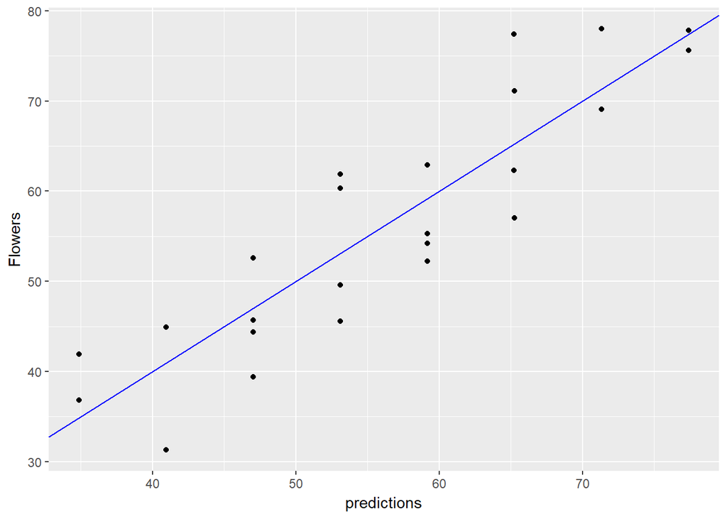

```r
# Predict the number of flowers on each plant
flowers$predictions <- predict(flower_model)

# Plot predictions vs actual flowers (predictions on x-axis)
ggplot(flowers, aes(x = predictions, y = Flowers)) +
  geom_point() +
  geom_abline(color = "blue")
```

### Modeling an interaction

In this exercise you will use interactions to model the effect of gender and gastric activity on alcohol metabolism.

The data frame `alcohol` has columns:

- `Metabol`: the alcohol metabolism rate
- `Gastric`: the rate of gastric alcohol dehydrogenase activity
- `Sex`: the sex of the drinker (Male or Female)

In the video, we fit three models to the alcohol data:

- one with only additive (main effect) terms : `Metabol ~ Gastric + Sex`
- two models, each with interactions between gastric activity and sex

We saw that one of the models with interaction terms had a better R-squared than the additive model, suggesting that using interaction terms gives a better fit. In this exercise we will compare the R-squared of one of the interaction models to the main-effects-only model.

```
x*y = x + y + x:y
```

**Instructions**

```r
alcohol <- read.csv("Data/2Regression/alcohol.csv")
```

The data frame `alcohol` is in your workspace.

- Write a formula that expresses `Metabol` as a function of `Gastric` and `Sex` with no interactions.
- Assign the formula to the variable `fmla_add` and print it.
- Write a formula that expresses `Metabol` as a function of the interaction between `Gastric` and `Sex`.
  - Add `Gastric` as a main effect, but not Sex.
  - Assign the formula to the variable `fmla_interaction` and print it.
- Fit a linear model with only main effects: `model_add` to the data.
- Fit a linear model with the interaction: `model_interaction` to the data.
- Call `summary()` on both models. Which has a better R-squared?

```r
# alcohol is in the workspace
# summary(alcohol)

# Create the formula with main effects only
(fmla_add <- as.formula("Metabol ~ Gastric + Sex"))
```

```
## Metabol ~ Gastric + Sex
```

```r
# Create the formula with interactions
(fmla_interaction <- as.formula("Metabol ~ Gastric + Gastric : Sex"))
```

```
## Metabol ~ Gastric + Gastric:Sex
```

```r
# Fit the main effects only model
model_add <- lm(fmla_add, alcohol)

# Fit the interaction model
model_interaction <- lm(fmla_interaction, alcohol)
```

```r
# Call summary on both models and compare
# summary(model_add)
# summary(model_interaction)

stargazer::stargazer(model_add, model_interaction, type = "html", single.row = T)
```

|  | *Dependent variable:* |  |
| --- | --- | --- |
|  | Metabol |  |
|  | (1) | (2) |
| Gastric | 1.966*** (0.267) | 1.149*** (0.345) |
| SexMale | 1.617*** (0.511) |  |
| Gastric:SexMale |  | 1.042*** (0.241) |
| Constant | -1.947*** (0.520) | -0.750 (0.531) |
| Observations | 32 | 32 |
| R<sup>2</sup> | 0.765 | 0.808 |
| Adjusted R<sup>2</sup> | 0.749 | 0.795 |
| Residual Std. Error (df = 29) | 1.331 | 1.204 |
| F Statistic (df = 2; 29) | 47.307*** | 61.048*** |
| *Note:* | p<0.1; p<0.05; p<0.01 |  |

## Dealing with Non-Linear Responses